# R for Marine Biology

Coral Performance - Galapagos Reef Revival

Daniel Velasco C.

2024-08-31

**Los datos utilizados de ejemplo aquí son parte del siguiente estudio**:

Dávalos, N., Velasco, D., Brandt, M. (in prep.). First Assessment of the Physiological Performance of Nursery Corals in the Galapagos Islands: Seasonal Growth and Mortality Rates.

Aquí resumo todos los pasos para trabajar con bases de datos: desde cargar paquetes e importar bases de datos hasta correr pruebas estadísticas y exportar gráficos.

[figure not shown]

Reef Revival Research Work

# 1 **Primeros Pasos**

## 1.1 Instalar y Cargar Paquetes

Para usar R, siempre debemos tener nuestros paquetes instalados y cargados. Se usa la función `install.packages()` para instalar paquetes que no has instalado antes. Para “cargar” (*load*) los paquetes que se van a utilizar se usa la función `library()`. Yo tengo los paquetes que necesito instalados pero pondré de ejemplo el código para instalar el paquete `rstatix`. Pero **siempre** al inicio de una nueva sesión en RStudio debes ejecutar `library()` con **todos** los paquetes que vas a utilizar.

```r
# install package
install.packages("rstatix")    #example
```

```r
# load package list
library(readxl)
library(tidyverse)
library(ggpubr)
library(ggtext)
library(ggrepel)
library(ggsci)
library(rstatix)
library(patchwork)
library(multcompView)
library(agricolae)
library(glue)
library(ggpmisc)
```

## 1.2 Importar Base de Datos

Tenemos que importar la base de datos (database) con la que vamos a trabajar. Pero para indicarle a RStudio donde se encuentra nuestra database, se usa la función `setwd()`. Este código permite configurar el directorio (directory), que es en palabras sencillas el sitio en tu computadora en el que R trabaja. La función `read_csv()` (paquete `readr`) importa archivos CSV mientras que `read_excel()` (paquete `readxl`) importa hojas de cálculo de Excel. Con el argumento `sheet =` especificas la pestaña del archivo de Excel que se va a importar.

```r
# import dataset
corals  <-  read_excel("Datos/Coral_Database.xlsx", sheet = "Growth")
```

El primer set de datos por revisar es la *Coral Growth Master Database* llamada `corals` en el código, que incluye las tasas de crecimiento de los corales tanto de la época caliente (Enero-Mayo 2022) como de la fría (Junio-Diciembre 2022). En 2021, Nicolás Dávalos identificó durante un estudio “baseline” en la bahía de Puerto Villamil diversas colonias de *Pocillopora*. De estas colonias se tomaron fragmentos para sembrarlos en un vivero con estructuras de cuerdas hasta que tengan el tamaño suficiente para ser transplantados al fondo marino. Según la colonia de origen y características morfológicas, los fragmentos del vivero se agruparon en **morfotipos**. Este primer grupo de fragmentos pertenece al **grupo piloto**. El objetivo de este grupo piloto fue evaluar la viabilidad de las técnicas de siembra de corales *Pocillopora* en Galápagos.

Si queremos trabajar con nuestra base de datos `corals`, tenemos que saber utilizar funciones en R.

## 1.3 ¿Qué es una función?

En R, una función es un bloque de código que realiza una tarea específica. Las funciones en R son fundamentales para estructurar y organizar el código, permitiendo realizar operaciones repetitivas de manera eficiente y clara.

Ya acabamos de utilizar varias funciones en este trabajo: `install.packages()` y `library()` para usar los paquetes y `read_excel()` para importar tablas.

Cada función tiene un nombre que se utiliza para invocarla o llamarla en el código. Las funciones pueden aceptar uno o más argumentos, que son los valores que se le pasan a la función para que opere sobre ellos.

**Ejemplo** Vamos a utilizar una función llamada `nrow()` para contar el número de filas en `corals`. También usaremos las funciones `mean()` y `range()` en la variable `dA` que indica las tasas de crecimiento de los corales en cm por cada 100 días. Para utilizar una variable dentro de una database, se usa el signo de dolar `$`.

```r
## ejemplos de funciones
nrow(corals)            # contar filas
```

```
## [1] 749
```

```r
mean(corals$dA)         # ver promedio de crecimiento de corales
```

```
## [1] 6.026231
```

```r
range(corals$dA)        # ver rango de valores de crecimiento
```

```
## [1]  0.04142857 24.77095238
```

Con estas tres primeras funciones, R nos ha indicado que nuestra database `corals` tiene 749 filas, que los corales tienen una tasa de crecimiento promedio de 6.026 cm/100d y han crecido entre 0.041 y 24.770 cm/100d.

```r
view(corals)            # abre interfaz en RStudio para ver base de datos
```

La función `view()` muestra la database en un visor que es parte de la interfaz de RStudio.

## 1.4 Data Management

Estos y otros cambios los podemos hacer con un paquete para manipulación de datos llamado `dplyr` que pertenece a la colección de paquetes `tidyverse`. En `dplyr` se trabaja con el *pipe operator* `%>%`.Este operador permite canalizar la salida de una función a la entrada de otra función. En lugar de anidar funciones, es decir leer desde adentro hacia afuera (e.g.`function2(function1())`), la idea de canalizar es leer las funciones de izquierda a derecha. Con esto, puedes hacer varias acciones de forma sencilla y fácil de leer.

**Funciones importantes de dplyr para dataframes**

**Básicas:**

- `filter()` seleccionar filas según una o varias condiciones.
- `select()` seleccionar columnas.
- `mutate()` crear o modificar columnas
- `mutate_at()` aplicar una función a varias columnas a la vez.
- `arrange()` ordenar filas según valores de una o más columnas.
- `rename()` renombrar columnas.
- `distinct()` eliminar filas duplicadas.
- `join()` combinar dos dataframes en función de una o más columnas clave.
- `pivot_longer()` convierte columnas en filas.
- `pivot_wider()` convierte filas en columnas.

**Tomar Muestras Aleatorias:**

- `sample_n()` selecciona un número específico de filas.
- `sample_frac()` selecciona una fracción del total de filas.

**Agrupar y Resumir:**

- `group_by()` agrupar datos en función de una o más variables.
- `summarise()` resumir datos con funciones matemáticas.

**Condicionales:**

- `case_when()` crear nuevas columnas con múltiples condiciones.
- `if_else()` hacer evaluaciones lógicas.

Y así podríamos estar todo el día: leyendo y aprendiendo funciones de `dplyr` (o de cualquier paquete de R). A lo largo de este trabajo usaremos varias de las funciones previamente mencionadas y otras nuevas adicionales. También es importante entender el significado de varios símbolos.

- `#` Todo lo que sigue a # en una línea no se ejecuta y se trata como un comentario.
- `$` acceder a elementos específicos en listas o a columnas en dataframes.
- `<-` o `=` asignar valores
- `==` comparar si dos valores son iguales.
- `%in%` verificar si un elemento o elementos pertenecen a un vector o conjunto de valores.
- `%>%` “Pipe Operator”, encadenar funciones
- `c()` concatenar elementos en un vector

```r
# eliminar fenotipos con pocos fragmentos
growth  <-  corals    %>% filter(!Phenotype %in% c("P2", "P5.2", "P9.2", "P19.2", "P6", "P?4", "PAC.PD"))

# seleccionar fragmentos del proyecto PILOTO
growth  <-  growth   %>% filter(Group == "Piloto")

# variables settings
growth  <-  growth        %>%
            filter(Plane  ==  "Horizontal")   %>%  #droplevels()           %>%
            #(seleccionar fotos en ángulo horizontal)
            mutate(Season    =  factor(Season,
                      levels = c("Warm 2022", "Cold 2022")))               %>%
            mutate(Phenotype = factor(Phenotype, levels = c(
            "P4", "P5", "P7", "P9", "P10", "P13", "P14", "P19")))          %>%
            mutate_at(c("Group", "Test", "Plane", "Fragment", "State"),
                      factor)
```

Nota: en R para decir “igual” se usa `"=="`. Por eso uso el código `filter(Group == "Piloto")`, para seleccionar las filas que cumplen con la condición de ser del grupo piloto. Los símbolos `"="` o `"<-"` se utilizan como asignadores de valores. Y la función `c()` significa concatenar elementos en un vector. Es una de las funciones más básicas y ampliamente utilizadas en R, ya que permite crear vectores, que son el tipo de dato más fundamental en el lenguaje.

**Ejemplo:**

```r
myvalue   =  2                         # crear objeto asignando un valor
myvalues1 <- c(1, 2, 3, 12, 14)        # crear vector con varios valores

## Si "==" devuelve TRUE, los valores son iguales. Si devuelve FALSE, no lo son.

myvalue   == 2                          # sí es igual
```

```
## [1] TRUE
```

```r
myvalue   == 12                         # no es igual
```

```
## [1] FALSE
```

```r
myvalues1 == c(1, 2, 3, 12, 14)         # sí
```

```
## [1] TRUE TRUE TRUE TRUE TRUE
```

```r
myvalues1 == c(1, 2, 5, 15, 20)         # no
```

```
## [1]  TRUE  TRUE FALSE FALSE FALSE
```

# 2 **Tasas de Crecimiento de Corales**

## 2.1 Exploración de Datos

Con los ajustes necesarios, ya tenemos la base de datos con la estructura correcta. Pero ahora, ¿queremos saber cómo son nuestros datos cierto? Para esto, podemos usar varias funciones para resumir y explorar la estructura y contenido de nuestro dataframe.

La función `str()` significa “structure” (estructura) y se utiliza para mostrar una descripción compacta de la estructura de un objeto R. Es muy útil para obtener una visión general rápida de las variables dentro de un objeto y su tipo de datos.

- Muestra el tipo de objeto: dataframe, tibble, lista, vector, etc.
- Muestra las dimensiones del objeto: Número de filas y columnas.
- Muestra el tipo de cada columna o elemento: Numérico, factor, carácter, etc.
- Expone una muestra de los datos: Unas pocas observaciones o valores para cada variable.

La función `summary()` proporciona un resumen estadístico de los contenidos de un objeto, generalmente un data frame.

- Para variables numéricas: Proporciona estadísticas descriptivas básicas como la media, el mínimo, el máximo, el primer y tercer cuartil, y la mediana.
- Para factores: Muestra el conteo de ocurrencias de cada nivel.
- Para datos lógicos: Muestra el número de `TRUE`, `FALSE`, y `NA` (si los hay).
- Para dataframes: Proporciona un resumen de cada columna.

```r
# Growth Master Database Summary
str(growth)
```

```
## tibble [232 × 13] (S3: tbl_df/tbl/data.frame)
##  $ Group    : Factor w/ 1 level "Piloto": 1 1 1 1 1 1 1 1 1 1 ...
##  $ Season   : Factor w/ 2 levels "Warm 2022","Cold 2022": 2 2 2 2 2 2 2 2 2 2 ...
##  $ Test     : Factor w/ 2 levels "Piloto - Cold",..: 1 1 1 1 1 1 1 1 1 1 ...
##  $ Phenotype: Factor w/ 8 levels "P4","P5","P7",..: 5 5 5 5 5 6 6 6 6 6 ...
##  $ Fragment : Factor w/ 20 levels "1","2","3","4",..: 1 2 3 4 5 1 2 3 4 5 ...
##  $ Plane    : Factor w/ 1 level "Horizontal": 1 1 1 1 1 1 1 1 1 1 ...
##  $ State    : Factor w/ 0 levels: NA NA NA NA NA NA NA NA NA NA ...
##  $ dA       : num [1:232] 3.45 3.4 2.28 2.47 3.51 ...
##  $ dP       : num [1:232] 5.36 2.67 2.37 6.61 8.35 ...
##  $ dML      : num [1:232] 0.146 0.697 0.188 0.504 0.227 ...
##  $ pdA      : num [1:232] 0.2 0.252 0.142 0.283 0.259 ...
##  $ pdP      : num [1:232] 0.1882 0.1421 0.0926 0.4091 0.3276 ...
##  $ pdML     : num [1:232] 0.0229 0.1429 0.0258 0.1095 0.0365 ...
```

```r
summary(growth)
```

```
##     Group           Season               Test       Phenotype     Fragment
##  Piloto:232   Warm 2022:124   Piloto - Cold:108   P5     :38   1      : 16
##               Cold 2022:108   Piloto - Warm:124   P9     :38   6      : 15
##                                                   P4     :34   9      : 15
##                                                   P19    :32   2      : 14
##                                                   P14    :31   3      : 14
##                                                   P13    :25   5      : 14
##                                                   (Other):34   (Other):144
##         Plane      State           dA                 dP
##  Horizontal:232   NA's:232   Min.   : 0.04143   Min.   : 0.09375
##                              1st Qu.: 3.57691   1st Qu.: 3.69741
##                              Median : 6.02187   Median : 5.87228
##                              Mean   : 6.71576   Mean   : 6.00921
##                              3rd Qu.: 9.17774   3rd Qu.: 7.98422
##                              Max.   :23.24238   Max.   :17.74429
##
##       dML                pdA                pdP                pdML
##  Min.   :0.005625   Min.   :0.004125   Min.   :0.005853   Min.   :0.001225
##  1st Qu.:0.714464   1st Qu.:0.412332   1st Qu.:0.226350   1st Qu.:0.129050
##  Median :0.999836   Median :0.601812   Median :0.303397   Median :0.188869
##  Mean   :1.006979   Mean   :0.691999   Mean   :0.341204   Mean   :0.208210
##  3rd Qu.:1.296406   3rd Qu.:0.928882   3rd Qu.:0.438399   3rd Qu.:0.267116
##  Max.   :2.314286   Max.   :2.257790   Max.   :1.113023   Max.   :0.691294
##
```

```r
summary(growth[["Phenotype"]]) #morfotipos suficientemente abundantes
```

```
##  P4  P5  P7  P9 P10 P13 P14 P19
##  34  38  21  38  13  25  31  32
```

La función `head()` muestra las primeras filas de un data frame, tibble, vector, o cualquier otro objeto similar. Muestra las primeras 6 filas de un objeto por defecto, pero puedes especificar el número de filas que deseas ver. La función `print()` se utiliza para mostrar cualquier objeto en la consola. Es una función básica en R que te permite ver el contenido de un objeto, y es especialmente útil para mostrar resultados intermedios o finales en un script.

`nrow()` devuelve el número de filas y `ncol()` devuelve el número de columnas de un data frame o matriz. `names()` devuelve o establece los nombres de las columnas de un data frame o los nombres de los elementos en un vector.

```r
head(growth)
```

```
## # A tibble: 6 × 13
##   Group  Season    Test   Phenotype Fragment Plane State    dA    dP   dML   pdA
##   <fct>  <fct>     <fct>  <fct>     <fct>    <fct> <fct> <dbl> <dbl> <dbl> <dbl>
## 1 Piloto Cold 2022 Pilot… P10       1        Hori… <NA>   3.45  5.36 0.146 0.200
## 2 Piloto Cold 2022 Pilot… P10       2        Hori… <NA>   3.40  2.67 0.697 0.252
## 3 Piloto Cold 2022 Pilot… P10       3        Hori… <NA>   2.28  2.37 0.188 0.142
## 4 Piloto Cold 2022 Pilot… P10       4        Hori… <NA>   2.47  6.61 0.504 0.283
## 5 Piloto Cold 2022 Pilot… P10       5        Hori… <NA>   3.51  8.35 0.227 0.259
## 6 Piloto Cold 2022 Pilot… P13       1        Hori… <NA>   5.10  8.89 0.9   0.241
## # ℹ 2 more variables: pdP <dbl>, pdML <dbl>
```

```r
nrow(growth)
```

```
## [1] 232
```

```r
ncol(growth)
```

```
## [1] 13
```

```r
names(growth)
```

```
##  [1] "Group"     "Season"    "Test"      "Phenotype" "Fragment"  "Plane"
##  [7] "State"     "dA"        "dP"        "dML"       "pdA"       "pdP"
## [13] "pdML"
```

También podemos resumir y explorar nuestros datos con las funciones de `dplyr` que revisamos en la sección anterior. `group_by()` y `summarize()`, en combinación con funciones lógicas y matemáticas pueden ser de gran utilidad.

**Funciones Matemáticas para Explorar Datos**

- `mean()` media
- `median()` mediana
- `sd()` desviación Estándar
- `var()` varianza
- `range()` rango
- `IQR()` rango intercuartil
- `max()` valor máximo
- `min()` valor mínimo
- `count()` cuenta las observaciones por grupo

```r
# mostrar crecimiento por temporadas
growth  %>% group_by(Season)  %>%
            summarise(mean = mean(pdA,  na.rm = T),
                      var  =  var(pdA,  na.rm = T),
                      count = n())
```

```
## # A tibble: 2 × 4
##   Season     mean    var count
##   <fct>     <dbl>  <dbl> <int>
## 1 Warm 2022 0.898 0.163    124
## 2 Cold 2022 0.455 0.0438   108
```

```r
# mostrar crecimiento por temporadas y morfotipos
growth  %>% group_by(Phenotype, Season)  %>%
            summarise(mean = mean(pdA,  na.rm = T),
              var = var(pdA,  na.rm = T),
                      count = n())
```

```
## # A tibble: 16 × 5
## # Groups:   Phenotype [8]
##    Phenotype Season     mean     var count
##    <fct>     <fct>     <dbl>   <dbl> <int>
##  1 P4        Warm 2022 0.737 0.0613     18
##  2 P4        Cold 2022 0.385 0.0554     16
##  3 P5        Warm 2022 0.791 0.0574     20
##  4 P5        Cold 2022 0.487 0.00992    18
##  5 P7        Warm 2022 0.814 0.133      11
##  6 P7        Cold 2022 0.423 0.0230     10
##  7 P9        Warm 2022 1.24  0.229      20
##  8 P9        Cold 2022 0.443 0.0207     18
##  9 P10       Warm 2022 0.472 0.0234      8
## 10 P10       Cold 2022 0.227 0.00319     5
## 11 P13       Warm 2022 1.16  0.238      14
## 12 P13       Cold 2022 0.246 0.0187     11
## 13 P14       Warm 2022 0.904 0.0973     16
## 14 P14       Cold 2022 0.478 0.0324     15
## 15 P19       Warm 2022 0.828 0.120      17
## 16 P19       Cold 2022 0.733 0.0330     15
```

El output de estos códigos muestra tablas que resumen de forma clara y sencilla nuestros datos. Yo decidí calcular la media (columna `mean`), la varianza (columna `var`) y el conteo de observaciones (columna `count`) de las tasas de crecimiento de los corales, agrupando los datos por temporada y por morfotipo también. Son muchas las funciones que te permiten describir estadísticamente tus datos.

**Otras funciones**

- `quantile()` cuartiles
- `cor()` coeficiente de correlación entre dos variables
- `cov()` covarianza entre dos variables

**Estandarización y Distribución**

- `scale()` Estandariza (normaliza) un conjunto de datos. Resta la media y divide por la desviación estándar.

**Modelos y Ajustes**

- `lm( y ~ x)` ajusta un modelo lineal
- `glm(y ~ x, family = binomial)` ajusta modelos lineales generalizados

## 2.2 ¿Nuestros Datos son Paramétricos?

Siempre hay que evaluar si los datos cumplen con los principios de normalidad y homocedasticidad (homogeneidad de las varianzas). Además, es necesario identificar *outliers* (datos anormales) y verificar que no hayan *extreme values* que puedan alterar los resultados de las pruebas estadísticas. Con todo el data management hecho y esto revisado, sabemos que nuestros datos son “limpios” y podemos escoger el test estadístico adecuado que nos indique si nuestra hipótesis nula se mantiene o rechaza.

### 2.2.1 Outliers & Extreme Values

Los outliers son observaciones que se desvían considerablemente del resto de los datos. Pueden ser mucho mayores o mucho menores que el resto de los valores en un conjunto de datos.

```r
# extreme values
growth %>%  group_by(Season, Phenotype)         %>%
            select(Season, `pdA`, Phenotype)    %>%
            identify_outliers(`pdA`)        #    %>%  filter(is.extreme == T)
```

```
## # A tibble: 5 × 5
##   Season    Phenotype   pdA is.outlier is.extreme
##   <fct>     <fct>     <dbl> <lgl>      <lgl>
## 1 Warm 2022 P5        0.268 TRUE       FALSE
## 2 Warm 2022 P5        0.263 TRUE       FALSE
## 3 Warm 2022 P13       2.26  TRUE       FALSE
## 4 Cold 2022 P4        1.07  TRUE       FALSE
## 5 Cold 2022 P19       1.14  TRUE       FALSE
```

### 2.2.2 Normalidad

En estadística, una **distribución normal**, distribución gaussiana o **normalidad estadística** es un tipo de distribución de probabilidad continua para una variable aleatoria de valor real. Se considera que un set de datos tiene normalidad si la media representa el centro de la distribución (`media = mediana`), el tamaño de la muestra es lo suficientemente grande `n = 30` y la gráfica de su función de densidad tiene una forma acampanada y simétrica.

Las distribuciones normales son importantes en estadística y se utilizan a menudo en las ciencias naturales para representar variables aleatorias de valor real cuyas distribuciones no se conocen. Hay varios métodos para saber si nuestros datos cumplen con el requisito de normalidad (pruebas de normalidad, Q-Q plots, histogramas, etc).

Primero, creamos un modelo con la variable numérica cuya distribución queremos poner a prueba en los tests y en los Q-Q plots.

```r
# normality
normal    <- lm(pdA  ~ Season, growth)           # create model
```

#### 2.2.2.1 Shapiro–Wilk test

El test de Shapiro-Wilk es una prueba estadística utilizada para determinar si un conjunto de datos sigue una distribución normal. Es particularmente útil para validar una de las suposiciones clave de muchos métodos estadísticos paramétricos, que es la normalidad de los datos. El test compara la distribución de los datos observados con un modelo de distribución normal. Como resultado puede ocurrir lo siguiente:

Hipótesis Nula (H0): La hipótesis nula del test es que los datos siguen una distribución normal. Hipótesis Alternativa (H1): La hipótesis alternativa es que los datos no siguen una distribución normal. Si el valor p es menor que un nivel de significancia predefinido (por ejemplo, 0.05), se rechaza la hipótesis nula, indicando que los datos probablemente no siguen una distribución normal.

Sin embargo, el test de Shapiro-Wilk se vuelve muy sensible a pequeñas desviaciones de la normalidad cuando el tamaño de muestra es grande. Esto significa que incluso las pequeñas desviaciones de la normalidad pueden ser detectadas como significativas.Si `n > 50`, aumenta la probabilidad de que el test cometa falso positivos (error tipo I).

```r
# Shapiro–Wilk test. Do not use if n > 50 (too sensitive to type II error)
shapiro_test(residuals(normal))
```

```
## # A tibble: 1 × 3
##   variable          statistic    p.value
##   <chr>                 <dbl>      <dbl>
## 1 residuals(normal)     0.959 0.00000389
```

Nuestros datos tienen 232 rows. Por lo tanto, así el test de Shapiro–Wilk no es la mejor opción. Sin embargo, el test puede ser muy útil cuando tus datos presentan “estratificación” o “segmentación” (cuando los datos están divididos en subgrupos). En nuestro caso, las mediciones de corales se agrupan en dos temporadas y en morfotipos:

```r
## by seasons
growth  %>%  group_by(Season)  %>% shapiro_test(pdA)
```

```
## # A tibble: 2 × 4
##   Season    variable statistic        p
##   <fct>     <chr>        <dbl>    <dbl>
## 1 Warm 2022 pdA          0.957 0.000578
## 2 Cold 2022 pdA          0.971 0.0201
```

Durante la temporada caliente se realizaron 124 mediciones exitosas y durante la fría, 108. Estos dos grupos siguen siendo muestras muy grandes.

```r
## by phenotypes
growth  %>%  group_by(Season, Phenotype)  %>% shapiro_test(pdA)
```

```
## # A tibble: 16 × 5
##    Season    Phenotype variable statistic      p
##    <fct>     <fct>     <chr>        <dbl>  <dbl>
##  1 Warm 2022 P4        pdA          0.945 0.355
##  2 Warm 2022 P5        pdA          0.924 0.116
##  3 Warm 2022 P7        pdA          0.970 0.890
##  4 Warm 2022 P9        pdA          0.965 0.637
##  5 Warm 2022 P10       pdA          0.938 0.588
##  6 Warm 2022 P13       pdA          0.942 0.439
##  7 Warm 2022 P14       pdA          0.920 0.171
##  8 Warm 2022 P19       pdA          0.949 0.440
##  9 Cold 2022 P4        pdA          0.853 0.0153
## 10 Cold 2022 P5        pdA          0.959 0.582
## 11 Cold 2022 P7        pdA          0.910 0.278
## 12 Cold 2022 P9        pdA          0.975 0.880
## 13 Cold 2022 P10       pdA          0.915 0.498
## 14 Cold 2022 P13       pdA          0.969 0.875
## 15 Cold 2022 P14       pdA          0.988 0.998
## 16 Cold 2022 P19       pdA          0.932 0.294
```

Al estratificar por morfotipos, como resultado, los valores de crecimiento de todos los morfotipos en ambas temporadas muestran una distribución normal. Solo P4 en la época fría no tiene valores normales. Pero se puede considerar que los estratos del set de datos en general sigue un modelo de distribución normal.

#### 2.2.2.2 Q-Q plot

Un gráfico Q-Q (*quantile–quantile plot*) es un gráfico de probabilidad para comparar dos distribuciones de probabilidad al representar gráficamente sus cuantiles entre sí. Permite evaluar visualmente si un conjunto de datos sigue una distribución normal. Este tipo de gráficos tienen dos dimensiones compuestas por los fitted values y los residuales.

- Los *theoretical quantiles* son los cuantiles de la distribución teórica (en este caso, normal) calculados a partir de los datos ajustados. Los *fitted values* (valores ajustados) son las predicciones del modelo para las observaciones en tu conjunto de datos. En cambio, los *residuals* son las diferencias entre los valores observados reales y los valores ajustados por el modelo. En otras palabras, representan la cantidad de variación en los datos que no es explicada por el modelo.

**Interpretación**

- **Ajuste Ideal:** La linealidad de los puntos sugiere que los datos se distribuyen normalmente. Si las dos distribuciones que se comparan son similares, los puntos del gráfico Q-Q se ubicarán aproximadamente en la línea de identidad y = x.
- **Desviaciones en los Extremos:** Si los puntos se desvían de la línea diagonal en los extremos (colas), esto indica que los datos tienen colas más pesadas o más ligeras que la distribución normal. Puede señalar que el modelo no está capturando adecuadamente la variabilidad en las colas de la distribución.
- **Curvatura:** Si los puntos se desvían sistemáticamente de la línea diagonal en forma de curva (por ejemplo, en forma de “S”), esto sugiere que los datos tienen una distribución diferente de la normal, como una distribución sesgada.

```r
head(normal$fitted.values)                       # fitted values
```

```
##         1         2         3         4         5         6
## 0.4550666 0.4550666 0.4550666 0.4550666 0.4550666 0.4550666
```

```r
head(normal$residuals)                           # residuals
```

```
##          1          2          3          4          5          6
## -0.2553027 -0.2027702 -0.3126590 -0.1717890 -0.1956655 -0.2137466
```

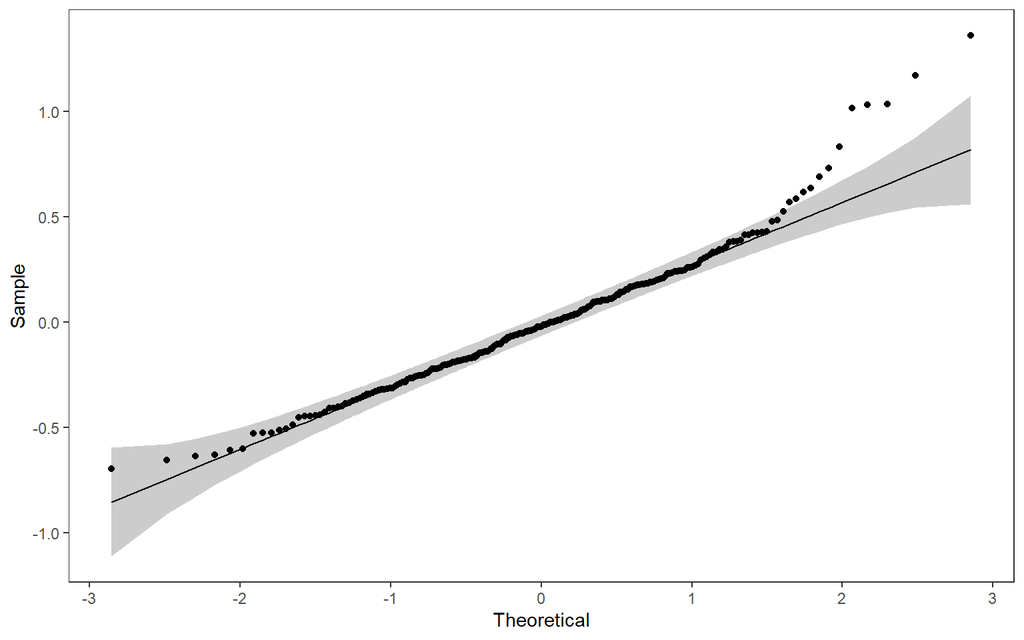

```r
ggqqplot(residuals(normal)) + theme_test()       # QQPLOT
```

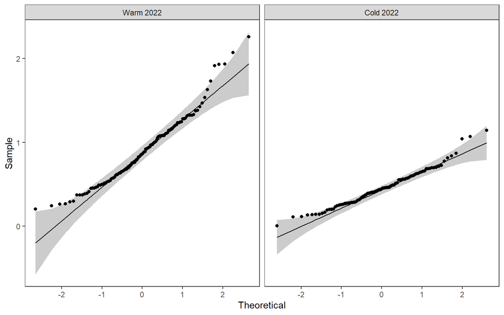

```r
# by seasons
ggqqplot(growth, "pdA", facet.by = "Season")    + theme_test()
```

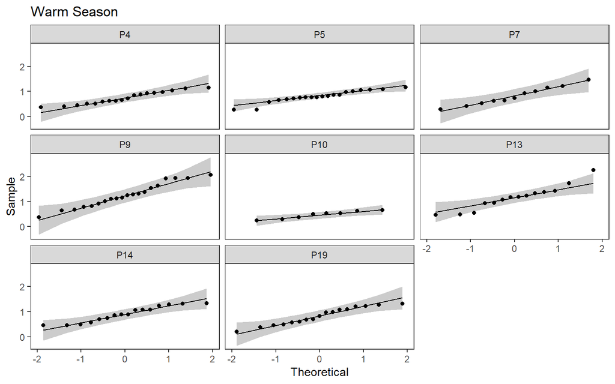

```r
# by morphotypes
#ggqqplot(growth, "pdA", facet.by = "Phenotype") + theme_test()

growth  %>% filter(Season == "Warm 2022")  %>%
  ggqqplot("pdA", facet.by = "Phenotype") +
  ggtitle("Warm Season") + theme_test()  # just warm season
```

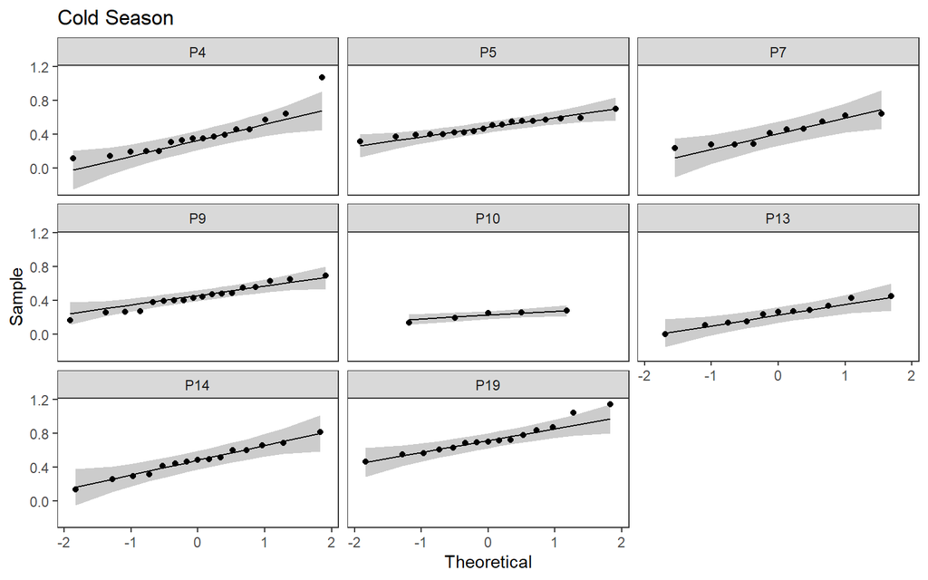

```r
growth  %>% filter(Season == "Cold 2022")  %>%
  ggqqplot("pdA", facet.by = "Phenotype") +
  ggtitle("Cold Season") + theme_test()  # just cold season
```

### 2.2.3 Homocedasticidad

La homocedasticidad es la condición en la que la varianza de los residuos (errores) es constante a lo largo de todos los niveles de las variables independientes. En otras palabras, los residuos deben tener una varianza constante sin importar el valor de la variable predictora.

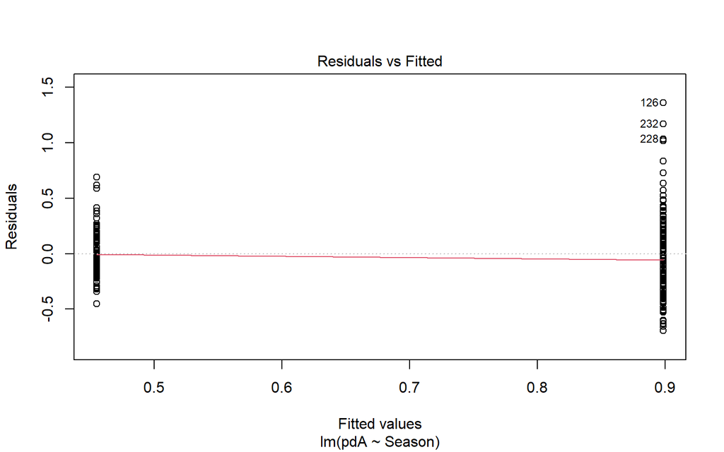

```r
# homogeneity of variance

# residuals vs fitted
plot(normal, 1)
```

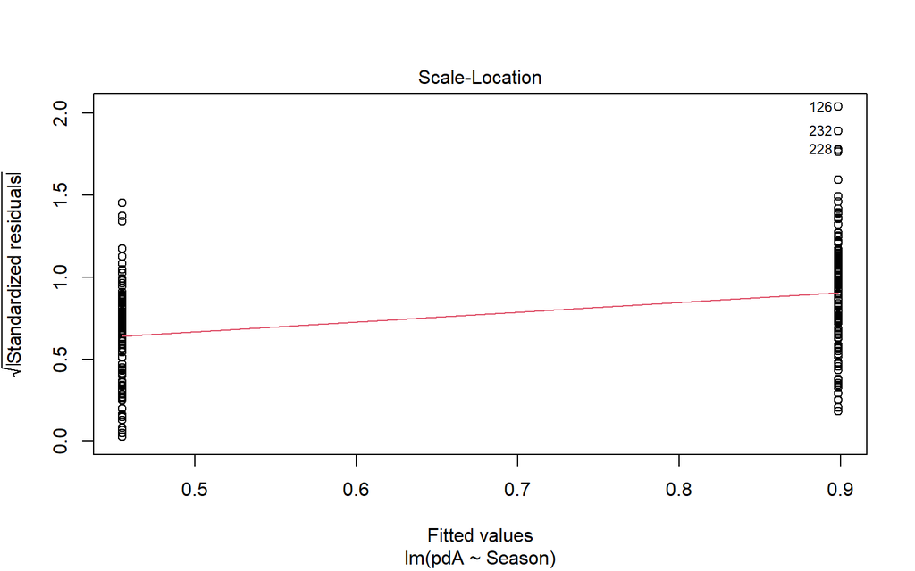

```r
plot(normal, 3)
```

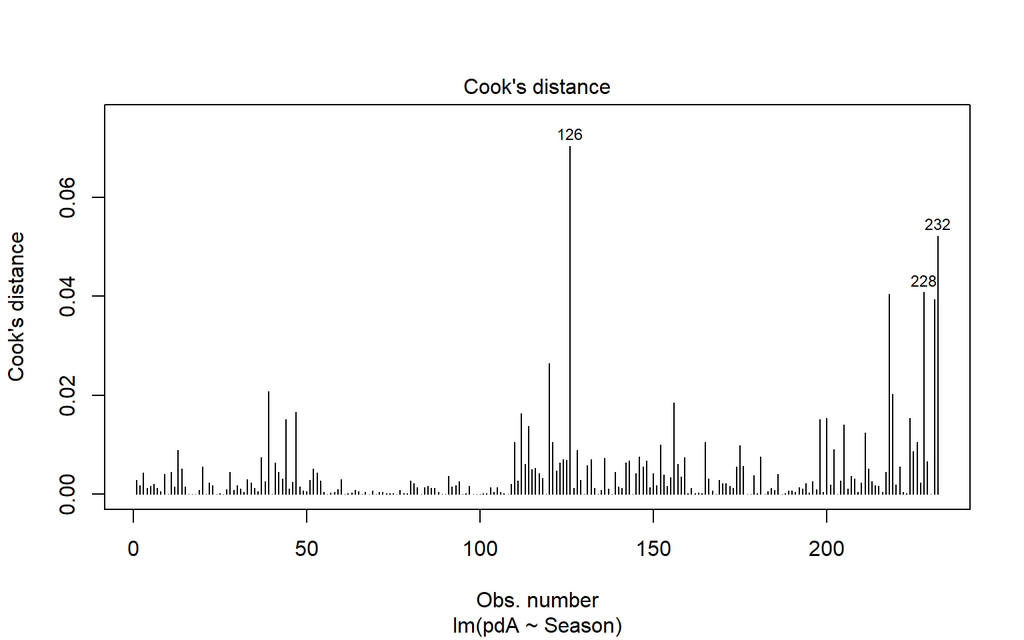

```r
plot(normal, 4)
```

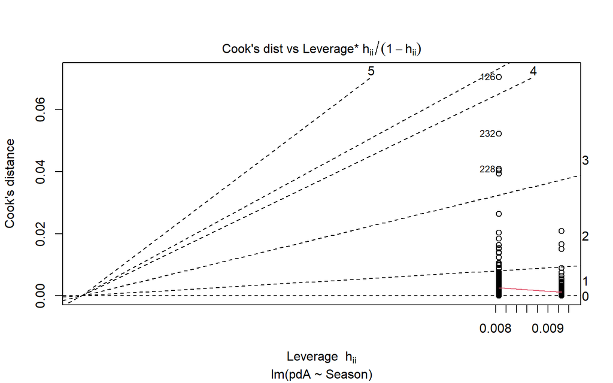

```r
plot(normal, 6)
```

```r
## Bartlett's test (more sensitive to deviations from normality)
bartlett.test(pdA ~ Season, growth)
```

```
##
##  Bartlett test of homogeneity of variances
##
## data:  pdA by Season
## Bartlett's K-squared = 44.676, df = 1, p-value = 2.325e-11
```

```r
## Levene's test (less sensitive)
growth  %>%  levene_test(pdA  ~ Season)
```

```
## # A tibble: 1 × 4
##     df1   df2 statistic            p
##   <int> <int>     <dbl>        <dbl>
## 1     1   230      34.5 0.0000000150
```

## 2.3 Diferencias en Crecimiento entre Temporadas y Morfotipos

### 2.3.1 Pruebas Estadísticas y Boxplots

```r
# STATS
## between seasons
t.test(pdA ~ Season, growth, paired = F, var.equal = F)
```

```
##
##  Welch Two Sample t-test
##
## data:  pdA by Season
## t = 10.689, df = 189.91, p-value < 2.2e-16
## alternative hypothesis: true difference in means between group Warm 2022 and group Cold 2022 is not equal to 0
## 95 percent confidence interval:
##  0.3614881 0.5250978
## sample estimates:
## mean in group Warm 2022 mean in group Cold 2022
##               0.8983596               0.4550666
```

```r
res.t    <- growth  %>%  t_test(pdA ~ Season) %>%  add_xy_position(x = "Season")
res.t
```

```
## # A tibble: 1 × 12
##   .y.   group1    group2     n1    n2 statistic    df        p y.position groups
##   <chr> <chr>     <chr>   <int> <int>     <dbl> <dbl>    <dbl>      <dbl> <name>
## 1 pdA   Warm 2022 Cold 2…   124   108      10.7  190. 3.52e-21       2.39 <chr>
## # ℹ 2 more variables: xmin <dbl>, xmax <dbl>
```

```r
res.tky  <- growth  %>%  tukey_hsd(pdA ~ Season) %>% add_xy_position(x = "Season")
res.tky
```

```
## # A tibble: 1 × 13
##   term   group1 group2 null.value estimate conf.low conf.high p.adj p.adj.signif
##   <chr>  <chr>  <chr>       <dbl>    <dbl>    <dbl>     <dbl> <dbl> <chr>
## 1 Season Warm … Cold …          0   -0.443   -0.528    -0.358     0 ****
## # ℹ 4 more variables: y.position <dbl>, groups <named list>, xmin <dbl>,
## #   xmax <dbl>
```

```r
            #this boxplot for later
p1   <-     ggplot(growth, aes(x = Season, y = pdA, col = Season), col = 1) +
            stat_boxplot(geom = "errorbar", width = .1) +
            geom_boxplot(aes(fill = Season)) + xlab("") +
            ylab("dA (%/100 days)") +
            stat_pvalue_manual(res.tky, hide.ns = F, label = "p.adj.signif") +
            stat_summary(fun = 'mean', geom = 'point', shape = 4) +
         #   stat_compare_means(method = "t.test", label.x = 1.5) +
            theme_test() + theme(legend.position = "none",
            plot.title = element_text(hjust = .5),
            text = element_text(family = "serif", size = 12)) +
            scale_y_continuous(labels = scales::percent) +
            scale_fill_manual( values = c("#D62728", "#1F77B4")) +
            scale_color_manual(values = c("#6b1414", "#103c5a")) +
            labs(subtitle = get_test_label(res.t, detailed = F,
            description = "Student's t-test"))

## between morphotypes
res.aov.morho <-  growth %>%  group_by(Season)  %>%
                              welch_anova_test(pdA ~ Phenotype)
res.aov.morho
```

```
## # A tibble: 2 × 8
##   Season    .y.       n statistic   DFn   DFd             p method
## * <fct>     <chr> <int>     <dbl> <dbl> <dbl>         <dbl> <chr>
## 1 Warm 2022 pdA     124       8.2     7  45.0 0.00000207    Welch ANOVA
## 2 Cold 2022 pdA     108      16.7     7  36.1 0.00000000137 Welch ANOVA
```

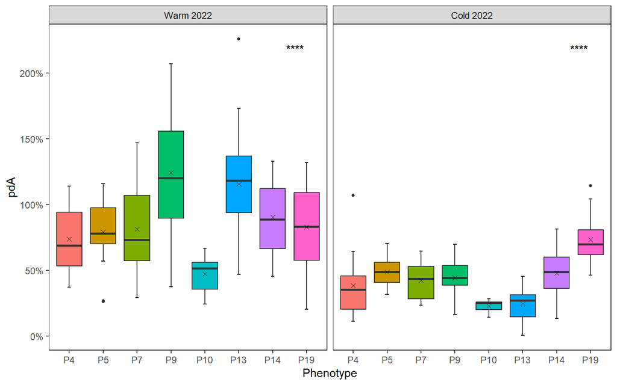

```r
ggplot(growth, aes(x = Phenotype, y = pdA)) +
            stat_boxplot(geom = "errorbar", width = .1) +
            geom_boxplot(aes(fill = Phenotype), outlier.size = 1) +
            stat_summary(fun = 'mean', geom = 'point', shape = 4) +
            facet_wrap(~Season) +
            stat_compare_means(method = "kruskal.test", label = "p.signif",
            label.x = 7.5, label.y = 2.15, hide.ns = T) +
            #ggtitle("Seasonal Coral Growth Rate by Phenotype") +
            theme_test() + theme(legend.position = "none",
            #plot.title = element_text(hjust = 0.5)
            ) + scale_y_continuous(labels = scales::percent)
```

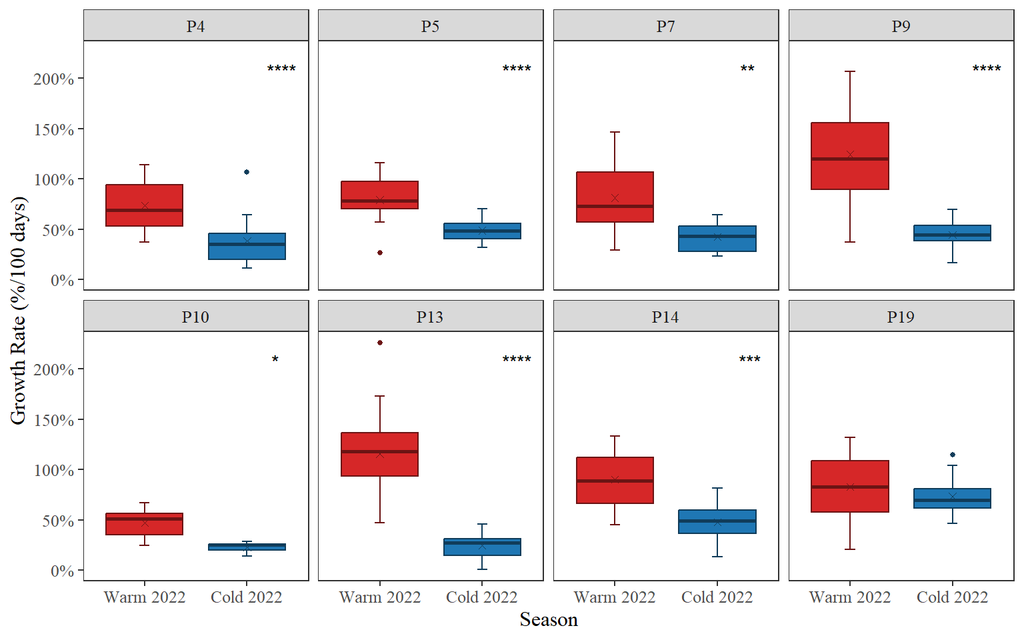

```r
## between seasons and morphotypes
ggplot(growth, aes(x = Season, y = pdA, col = Season)) +
            stat_boxplot(geom = "errorbar", width = .1) +
            geom_boxplot(aes(fill = Season), outlier.size = 1) +
            stat_summary(fun = 'mean', geom = 'point', shape = 4) +
            stat_compare_means(method = "wilcox.test", label = "p.signif",
            label.x = 2.25, label.y = 2, hide.ns = T) +
            facet_wrap(~Phenotype, ncol = 4) +
            #ggtitle("Seasonal Coral Growth Rate by Morphotype") +
            ylab("Growth Rate (%/100 days)") +
            theme_test() + theme(legend.position = "none",
            #plot.title = element_text(hjust = 0.5),
            text = element_text(family = "serif", size = 12)) +
            scale_color_manual(values = c("#6b1414", "#103c5a")) +
            scale_fill_manual(values  = c("#D62728", "#1F77B4")) +
            scale_y_continuous(labels = scales::percent)
```

## 2.4 Comparación con Grupo Control

```r
# select morphotypes
t_vs_p   <-   corals %>%  filter(Phenotype %in% c("P4", "P9", "P13"))

# factors
t_vs_p   <-   t_vs_p %>%  filter(Plane == "Horizontal")               %>%
                          mutate_at(c("Group", "Season",
                          "Plane", "Fragment", "State"), factor)      %>%
                          mutate(Phenotype = factor(Phenotype,
                          levels = c("P13", "P9", "P4")))             %>%
                          mutate(Test = factor(Test, levels = c(
                          "Piloto - Warm",
                          "Piloto - Cold", "Control - Cold")))

head(t_vs_p)
```

```
## # A tibble: 6 × 13
##   Group   Season   Test  Phenotype Fragment Plane State    dA    dP    dML   pdA
##   <fct>   <fct>    <fct> <fct>     <fct>    <fct> <fct> <dbl> <dbl>  <dbl> <dbl>
## 1 Testigo Cold 20… Cont… P13       2        Hori… <NA>   2.56 3.40  0.344  0.320
## 2 Testigo Cold 20… Cont… P13       3        Hori… <NA>   1.26 2.29  0.202  0.129
## 3 Testigo Cold 20… Cont… P13       7        Hori… <NA>   1.13 0.203 0.0425 0.203
## 4 Testigo Cold 20… Cont… P13       12       Hori… <NA>   1.29 1.43  0.477  0.213
## 5 Testigo Cold 20… Cont… P13       13       Hori… <NA>   1.80 1.14  0.398  0.340
## 6 Testigo Cold 20… Cont… P13       14       Hori… <NA>   2.84 0.604 0.792  0.289
## # ℹ 2 more variables: pdP <dbl>, pdML <dbl>
```

```r
summary(t_vs_p)
```

```
##      Group          Season               Test    Phenotype    Fragment
##  Piloto :97   Cold 2022:75   Piloto - Warm :52   P13:33    2      : 9
##  Testigo:30   Warm 2022:52   Piloto - Cold :45   P9 :51    3      : 9
##                              Control - Cold:30   P4 :43    4      : 8
##                                                            10     : 8
##                                                            1      : 7
##                                                            5      : 7
##                                                            (Other):79
##         Plane      State           dA                 dP
##  Horizontal:127   NA's:127   Min.   : 0.04143   Min.   : 0.03562
##                              1st Qu.: 2.48665   1st Qu.: 2.54884
##                              Median : 4.49688   Median : 4.56952
##                              Mean   : 5.15898   Mean   : 5.15432
##                              3rd Qu.: 7.21155   3rd Qu.: 7.54095
##                              Max.   :19.95238   Max.   :14.51952
##
##       dML                pdA                pdP                pdML
##  Min.   :0.003125   Min.   :0.004125   Min.   :0.002508   Min.   :0.0005817
##  1st Qu.:0.584063   1st Qu.:0.274999   1st Qu.:0.154214   1st Qu.:0.1077719
##  Median :0.898750   Median :0.481227   Median :0.277756   Median :0.1802121
##  Mean   :0.968018   Mean   :0.649490   Mean   :0.319061   Mean   :0.2140718
##  3rd Qu.:1.294687   3rd Qu.:0.957757   3rd Qu.:0.413218   3rd Qu.:0.2846022
##  Max.   :2.476250   Max.   :2.257790   Max.   :1.113023   Max.   :0.6912938
##
```

```r
# Welch ANOVA test (Area)
res.aov  <-   t_vs_p %>% welch_anova_test(pdA ~ Test)
res.aov
```

```
## # A tibble: 1 × 7
##   .y.       n statistic   DFn   DFd        p method
## * <chr> <int>     <dbl> <dbl> <dbl>    <dbl> <chr>
## 1 pdA     127      45.1     2  62.2 7.83e-13 Welch ANOVA
```

```r
# Games-Howell test (pairwise)
pwc      <-   t_vs_p  %>%    games_howell_test(pdA ~ Test)  %>%
                              add_xy_position(x = "Test")

pwc$p.adj.signif <-  gsub("ns", "", pwc$p.adj.signif)
pwc
```

```
## # A tibble: 3 × 12
##   .y.   group1        group2    estimate conf.low conf.high   p.adj p.adj.signif
##   <chr> <chr>         <chr>        <dbl>    <dbl>     <dbl>   <dbl> <chr>
## 1 pdA   Piloto - Warm Piloto -… -0.670     -0.840    -0.500 0       "****"
## 2 pdA   Piloto - Warm Control … -0.666     -0.900    -0.432 8.46e-9 "****"
## 3 pdA   Piloto - Cold Control …  0.00408   -0.187     0.195 9.99e-1 ""
## # ℹ 4 more variables: y.position <dbl>, groups <named list>, xmin <dbl>,
## #   xmax <dbl>
```

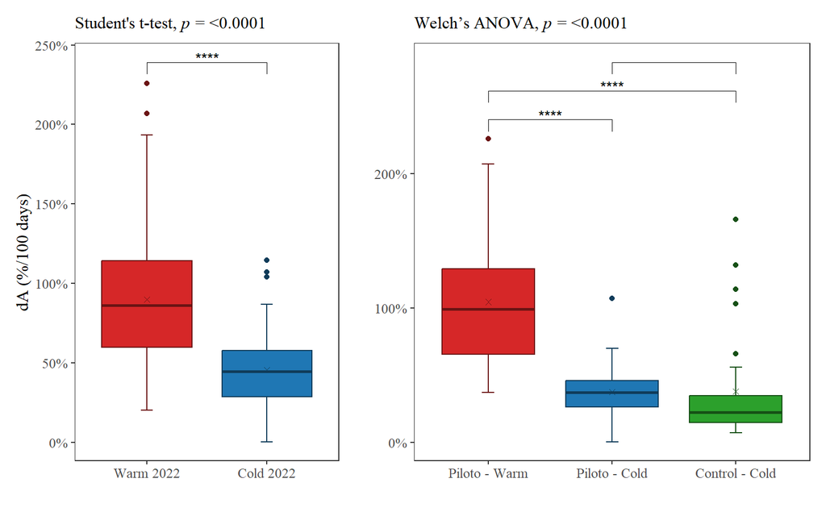

```r
# Boxplot with control group
p2      <-  ggplot(t_vs_p, aes(x = Test, y = `pdA`, col = Test), col = 1) +
            stat_boxplot(geom = "errorbar", width = 0.1) +
            geom_boxplot(aes(fill = Test)) +
            stat_summary(fun = 'mean', geom = 'point', shape = 4) +
            #stat_welch_anova_test(label.y = .98) +
            stat_pvalue_manual(pwc, hide.ns = F) + xlab("") + ylab("") +
            theme_test() + theme(legend.position = "none",
            plot.title = element_text(hjust = 0.5),
            text = element_text(family = "serif", size = 12)) +
            scale_y_continuous(labels = scales::percent) +
            scale_color_manual(values = c("#6b1414", "#103c5a", "#165016")) +
            scale_fill_manual(values  = c("#D62728", "#1F77B4", "#2CA02C")) +
         #   scale_color_hue(l = 25) +
            labs(subtitle = get_test_label(res.aov, detailed = F,
            description = "Welch’s ANOVA"))

# composite graph
wrap_plots(p1, p2, widths = c(0.4, 0.6))
```

# 3 **Tasas de Mortalidad de Corales**

## 3.1 Monitoreo de Corales en el Vivero

Las siguientes variables a analizar son la tasa de mortalidad (proporción de fragmentos de cada morfotipo que murieron) y el tejido muerto (superficie afectada por blanqueamiento, enfermedades o depredación).

El próximo gráfico evalúa las tasas de mortalidad y tejido muerto de cada morfotipo a lo largo del tiempo.

```r
head(mortal.month)
```

```
## # A tibble: 6 × 6
##   Month Morphotype `Live Tissue` `Dead Tissue` Survival Mortality
##   <fct> <fct>              <dbl>         <dbl>    <dbl>     <dbl>
## 1 Aug   P10                0.855        0.145      1         0
## 2 Aug   P13                0.924        0.0760     0.9       0.1
## 3 Aug   P14                0.8          0.2        0.9       0.1
## 4 Aug   P19                0.96         0.04       1         0
## 5 Aug   P3                 0.5          0.5        1         0
## 6 Aug   P4                 0.895        0.105      0.95      0.05
```

```r
summary(mortal.month)
```

```
##      Month      Morphotype  Live Tissue      Dead Tissue        Survival
##  May    :11   P3     : 8   Min.   :0.1000   Min.   :0.0000   Min.   :0.3077
##  Jun    :11   P4     : 8   1st Qu.:0.7105   1st Qu.:0.0460   1st Qu.:0.9000
##  Jul    :11   P5     : 8   Median :0.8710   Median :0.1290   Median :0.9875
##  Aug    :11   P6     : 8   Mean   :0.7983   Mean   :0.2017   Mean   :0.9223
##  Sep    :11   P7     : 8   3rd Qu.:0.9540   3rd Qu.:0.2895   3rd Qu.:1.0000
##  Oct    :11   P9     : 8   Max.   :1.0000   Max.   :0.9000   Max.   :1.0000
##  (Other):22   (Other):40
##    Mortality
##  Min.   :0.0000
##  1st Qu.:0.0000
##  Median :0.0125
##  Mean   :0.0777
##  3rd Qu.:0.1000
##  Max.   :0.6923
##
```

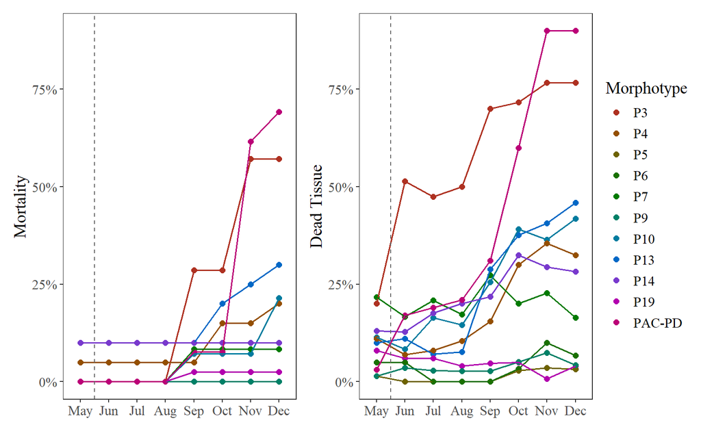

```r
ggplot(mortal.month, aes(x = Month, y = Mortality,
            group = Morphotype, col = Morphotype)) +
            geom_point(size = 2) + geom_line(linewidth = .7) +
            theme_test() + theme(text = element_text(family = "serif", size = 14),
            legend.position = "none", plot.title = element_text(hjust = .5)) +
            scale_color_hue(l = 40) + labs(x = element_blank()) +
            scale_y_continuous(limits = c(0,.9), labels = scales::percent) +
            geom_vline(xintercept = 1.5, linetype = "dashed", col = "grey40") +
ggplot(mortal.month, aes(x = Month, y = `Dead Tissue`,
            group = Morphotype, col = Morphotype)) +
            geom_point(size = 2) + geom_line(linewidth = .7, show.legend = F) +
            theme_test() + theme(text = element_text(family = "serif", size = 14),
            plot.title = element_text(hjust = .5)) +
            scale_color_hue(l = 40) + labs(x = element_blank()) +
            scale_y_continuous(limits = c(0,.9), labels = scales::percent) +
            geom_vline(xintercept = 1.5, linetype = "dashed", col = "grey40")
```

## 3.2 Correlación entre Crecimiento y Mortalidad

Una pregunta interesante que surgió como una impresión general en campo es si los corales con menor crecimiento también son los que tienen mayor mortalidad y menos supervivencia. Para responder a esta pregunta, se hace un **modelo lineal** para evaluar si hay una **correlación significativa** entre estas variables: **crecimiento vs mortalidad & tejido muerto**.

En una tabla incluimos la tasa de crecimiento promedio de cada morfotipo y las tasas de mortalidad y tejido muerto.

```r
head(mortal.net)
```

```
## # A tibble: 6 × 7
##   Phenotype Mortality FinalLiveTissue FinalDeadTissue meanLiveTissue
##   <fct>         <dbl>           <dbl>           <dbl>          <dbl>
## 1 P3           0.571            0.233          0.767           0.420
## 2 PAC-PD       0.692            0.1            0.9             0.586
## 3 P19          0.025            0.96           0.04            0.952
## 4 P14          0.1              0.718          0.282           0.781
## 5 P9           0                0.957          0.0430          0.963
## 6 P7           0.0833           0.836          0.164           0.796
## # ℹ 2 more variables: meanDeadTissue <dbl>, `mean%dA` <dbl>
```

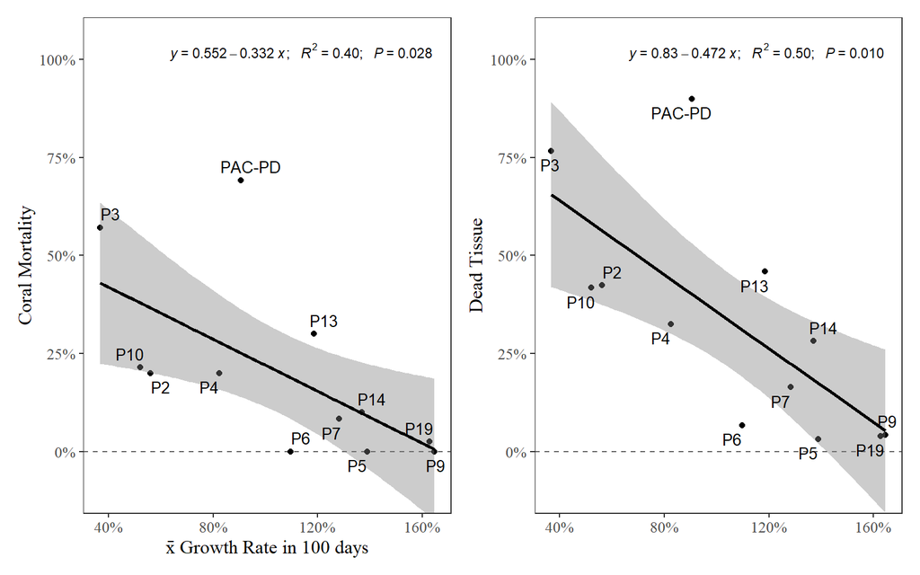

```r
# scatter plots, linear regression || coral growth v. deadth
# 1
ggplot(mortal.net, aes(x = `mean%dA`, y = `Mortality`)) +
        geom_hline(yintercept = 0, linetype = "dashed", col = "grey40") +
        geom_point() + geom_smooth(method = "glm", se = T, col = 1,
        fill = "grey50") +
        stat_poly_eq(aes(label = paste(..eq.label.., ..rr.label..,
        ..p.value.label.., sep = "*\";   \"*")),
        label.x = "right", label.y = "top", size = 3) +
        geom_text_repel(label = mortal.net$Phenotype, size = 3.5) +
        labs(
        #title = "Performance of Corals from Pilot Nursery",
        y = "Coral Mortality", x = "x̄ Growth Rate in 100 days") +
        theme_test() +
        theme(
        text = element_text(family = "serif", size = 12),
        legend.position = "none") +
        scale_x_continuous(labels = scales::percent) +
        scale_y_continuous(labels = scales::percent) +
        coord_cartesian(ylim = c(-0.1, 1.05)) +
#2
ggplot(mortal.net, aes(x = `mean%dA`, y = FinalDeadTissue)) +
        geom_hline(yintercept = 0, linetype = "dashed", col = "grey40") +
        geom_point() + geom_smooth(method = "glm", se = T, col = 1,
        fill = "grey50") +
        stat_poly_eq(aes(label = paste(..eq.label.., ..rr.label..,
        ..p.value.label.., sep = "*\";   \"*")),
        label.x = "right", label.y = "top", size = 3) +
        geom_text_repel(label = mortal.net$Phenotype,  size = 3.5) +
        labs(x = "", y = "Dead Tissue") +
        theme_test() +
        theme(
        text = element_text(family = "serif", size = 12),
        legend.position = "none") +
        scale_x_continuous(labels = scales::percent) +
        scale_y_continuous(labels = scales::percent) +
        coord_cartesian(ylim = c(-0.1, 1.05))
```

# 4 **Futuros Análisis**

En los próximos meses compartiré nuevos avances, esta vez relacionados con los fragmentos del vivero de la bahía. Los análisis previos son del grupo piloto (para evaluar la viabilidad de los fragmentos en el vivero). En este siguiente estudio que será mi tesis de pregrado evaluamos el efecto de variables ambientales oceanográficas (e.g. temperatura, salinidad, etc) obtenidas con un logger multiparámetro en las tasas de crecimiento de los fragmentos de *Pocillopora*. También, compartiremos resultados del primer inventario de diversidad de macroinvertebrados simbiontes en los fragmentos de *Pocillopora* del vivero.

# 5 **Recursos**

- [Animals in Motion - 2018 Workshop](https://vinayudyawer.github.io/Animals-in-Motion-2018/Documents/OCS2018.html)
- [Spatial Data Science with R](https://rspatial.org/)
- [dplyr package](https://dplyr.tidyverse.org/)
- [The R Graph Gallery](https://r-graph-gallery.com)
- [R Charts by R Coder](https://r-charts.com/)
- [Community Ecology Data in R](https://www.davidzeleny.net/anadat-r/doku.php/en:start)

# 6 **Referencias**

Edgar, G. J., Banks, S. A., Brandt, M., Bustamante, R. H., Chiriboga, A., Earle, S. A., … & Wellington, G. M. (2010). El Niño, grazers and fisheries interact to greatly elevate extinction risk for Galapagos marine species. Global Change Biology, 16(10), 2876-2890. https://doi.org/10.1111/j.1365-2486.2009.02117.x

García‐Medrano, D., López‐Pérez, A., Guendulain‐García, S., Valencia‐Méndez, O., Granja‐Fernández, R., González‐Mendoza, T., & Torres‐Hernández, P. (2023). Gardening Pocillopora spp. fragments and their potential for rebuilding reef systems in the southern Mexican Pacific. Restoration Ecology, 31(8), e14006. https://doi.org/10.1111/rec.14006

Ishida‐Castañeda, J., Pizarro, V., López‐Victoria, M., & Zapata, F. A. (2020). Coral reef restoration in the Eastern Tropical Pacific: feasibility of the coral nursery approach. Restoration Ecology, 28(1), 22-28. https://doi.org/10.1111/rec.13047

Lizcano-Sandoval, L. D., Londoño-Cruz, E., & Zapata, F. A. (2018). Growth and survival of Pocillopora damicornis (Scleractinia: Pocilloporidae) coral fragments and their potential for coral reef restoration in the Tropical Eastern Pacific. Marine biology research, 14(8), 887-897. https://doi.org/10.1080/17451000.2018.1528011

McCarthy, O. S., Winston Pomeroy, M., & Smith, J. E. (2024). Corals that survive repeated thermal stress show signs of selection and acclimatization. PloS one, 19(7), e0303779. https://doi.org/10.1371/journal.pone.0303779

Williams, S. L., Sur, C., Janetski, N., Hollarsmith, J. A., Rapi, S., Barron, L., … & Mars, F. (2019). Large‐scale coral reef rehabilitation after blast fishing in Indonesia. Restoration ecology, 27(2), 447-456. https://doi.org/10.1111/rec.12866